# AUEB M.Sc. in Data Science (part-time)

# Τρίμηνο: Εαρινό 2019

# Μάθημα: Numerical Optimization and Large Scale Linear Algebra

# Διδάσκων: Παρ. Βασσάλος

# Φοιτητής: Σπύρος Πολίτης (p3351814)

# ΑΣΚΗΣΗ 3

# Table of Contents

## Preliminaries

In the file Stanweb.dat, you will find in compressed form the connectivity matrix for the webpages of Stanford University. Specifically in the first column are contained the nodes while in the second the node with which is connected. Using the notation of the tutorial pagerank.pdf do the following:

### Import 3rd-party and bespoke packages

A brief description of the code implemented for this homework follows:

- Class *DataHelper*: implements the backbone of loading, preparing and transforming data required for the homework.
- Class *PageRank*: implements the *Power* and *Gauss-Seidel* methods.
- Class *VisualizationHelper*: implements all code for the required visualizations of this homework.

```python
# Import required packages.
import sys
import warnings
import numpy as np
import pandas as pd
import networkx as nx
from IPython.display import Markdown as md

warnings.filterwarnings('ignore')
```

```python
# Import required classes, implemented for the homework.
sys.path.append('code')

from DataHelper import DataHelper
from VisualizationHelper import VisualizationHelper
```

### Ingest and transform data

Knowing that $\mathbf{P}$ is sparse, I had to be creative in its representation. The problem of page links clearly lends itself to a graph representation, therefore my first step was to represent the *Stanford* page graph as a graph structure, requiring $O(n)$ time for the computation of its representation and then acquire the graph adjacency list as a *Scipy sparse column array*. For this purpose, I used the Python package *NetworkX*, which provides a solid implementation of a graph structure. For the graph representation, the correct data structure to be used is the *directed graph (DiGraph)*, since each node can have either incoming or outgoing links.

*NetworkX* also provides convenient methods to convert the graph to a *Scipy* *sparse row matrix*, which will be used subsequently for all algorithmic calculations, as well as for fascilities to visually inspect parts of the graph and validate its structure.

The *DataHelper* class provides the initial loading of *stanweb.dat* and its representation as a *Pandas DataFrame*. It also produces the *NetworkX* graph and the *Scipy* sparse row matrix upon data loading, so as they are made available to the algorithm implemented for the rest of the homework.

```python
data_helper = DataHelper()
visualization_helper = VisualizationHelper()
```

```python
%%time

# Ingest the data file as a Pandas DataFrame.
data_helper = data_helper.ingest_data('stanweb.dat')
```

```
CPU times: user 19.6 s, sys: 363 ms, total: 20 s
Wall time: 20 s
```

```python
%%time

page_links_df = data_helper.dataframe

md('Number of page links: %s.' % page_links_df.shape[0])
```

```
CPU times: user 272 µs, sys: 7 µs, total: 279 µs
Wall time: 170 µs
```

Number of page links: 2382912.

Check that data was loaded properly, as a Pandas DataFrame. In this instance, we shall inspect the incoming and outgoing links of node $5$, chosen at random:

```python
page_links_df[(page_links_df[0] == 5) | (page_links_df[1] == 5)]
```

|  | 0 | 1 | 2 |
| --- | --- | --- | --- |
| 38 | 5 | 220513 | 0.142857 |
| 39 | 5 | 170452 | 0.142857 |
| 40 | 5 | 134375 | 0.142857 |
| 41 | 5 | 59745 | 0.142857 |
| 42 | 5 | 67503 | 0.142857 |
| 43 | 5 | 6545 | 0.142857 |
| 44 | 5 | 14395 | 0.142857 |
| 54781 | 6545 | 5 | 0.142857 |
| 121417 | 14395 | 5 | 0.047619 |
| 502507 | 59745 | 5 | 0.142857 |

Inspect the graph object:

```python
md(nx.info(data_helper.graph))
```

Name: Google matrix graph Type: DiGraph Number of nodes: 281903 Number of edges: 2312497 Average in degree: 8.2032 Average out degree: 8.2032

Visualize the subgraph of page $5$:

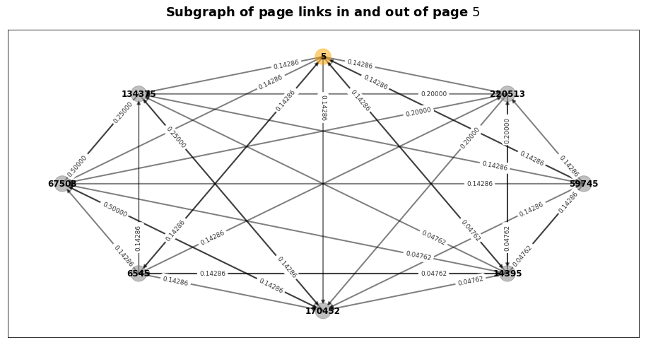

```python
nodes_1 = np.unique(page_links_df[page_links_df[0].isin([5])][0])
nodes_2 = np.unique(page_links_df[page_links_df[0].isin([5])][1])
nodes_1_2 = np.concatenate([nodes_1, nodes_2])

subgraph = data_helper.graph.subgraph(nodes_1_2)

visualization_helper.plot_graph(subgraph, highlight_nodes = [5], size = (16, 8), title = 'Subgraph of page links in and out of page $5$')

pass;
```

Inspect the sparse row matrix by printing the first 2 page links:

```python
print(data_helper.sparse_row_matrix[0:2, :])
```

```
  (0, 6547)	0.5
  (0, 15408)	0.5
  (1, 17793)	0.032258064516129
  (1, 25201)	0.032258064516129
  (1, 53624)	0.032258064516129
  (1, 54581)	0.032258064516129
  (1, 64929)	0.032258064516129
  (1, 73763)	0.032258064516129
  (1, 84476)	0.032258064516129
  (1, 98627)	0.032258064516129
  (1, 100192)	0.032258064516129
  (1, 102354)	0.032258064516129
  (1, 105317)	0.032258064516129
  (1, 105729)	0.032258064516129
  (1, 115925)	0.032258064516129
  (1, 140863)	0.032258064516129
  (1, 163549)	0.032258064516129
  (1, 164598)	0.032258064516129
  (1, 175798)	0.032258064516129
  (1, 178641)	0.032258064516129
  (1, 181713)	0.032258064516129
  (1, 190452)	0.032258064516129
  (1, 204188)	0.032258064516129
  (1, 204603)	0.032258064516129
  (1, 210869)	0.032258064516129
  (1, 213965)	0.032258064516129
  (1, 225118)	0.032258064516129
  (1, 241595)	0.032258064516129
  (1, 243293)	0.032258064516129
  (1, 246896)	0.032258064516129
  (1, 251657)	0.032258064516129
  (1, 252914)	0.032258064516129
  (1, 280934)	0.032258064516129
```

## Part (1)

### Part (a)

Find the vector $\pi$ with

```
i) the Power method
```

```
ii) solving the corresponding system
```

as they described in paragraph 5.1 and 5.2 of the tutorial. For both methods consider as $\alpha$ = 0.85 and stopping criterion $\tau = 10^{−8}$ and the vector a having $1$ if it is corresponds to a node with no out links and $0$ otherwise. Are the results the same for both methods? Which method seems to be faster? Use Gauss Seidel method for the iterative solution of the system.

#### Answer 1.a.i.

##### Power method implementation, alpha = 0.85

As mentioned in [1], the *Power iteration* (also known as the *Power method*) is an eigenvalue algorithm: given a diagonalizable matrix $\mathbf{A}$, the algorithm will produce a number ${\lambda}$, which is the greatest (in absolute value) eigenvalue of $\mathbf{A}$, and a nonzero vector $\mathbf{v}$, the corresponding eigenvector of $\lambda$, such that $\mathbf{A} \mathbf{v} = \lambda \mathbf{v}$.

PageRank is determined by computing the stationary solution $\pi^{T}$ of the hyperlink structure of the web, represented as a Markov chain with a transition probability matrix $\mathbf{P}$. The row vector $\pi^{T}$ can be found by solving the eigenvector problem $\pi^{T} \overline{\overline{P}}= \pi^{T}$, which translates to user power iterations for expression (1) of par. 5.1 of [2].

```python
from IPython.display import Markdown as md
```

```python
# Import required classes, implemented for the homework.
sys.path.append('code')

from PageRank import PageRank
```

```python
# Create an instance of my PageRank class.
pr_p_1ai = PageRank()
```

```python
# Get data as a sparse row matrix.
P_1ai = data_helper.sparse_row_matrix
```

```python
%%time

pr_p_1ai = pr_p_1ai.solve(P = P_1ai, alpha = 0.85, tol = 1e-08, method = 'power', verbose = False)
```

```
CPU times: user 7.52 s, sys: 211 ms, total: 7.73 s
Wall time: 7.73 s
```

```python
md('The algorithm converged in $%i$ iterations.' % (pr_p_1ai.iterations))
```

The algorithm converged in $98$ iterations.

```python
md('Inspect the output of the algorithm:\n\n %s.' % pr_p_1ai.x.toarray()[0])
```

Inspect the output of the algorithm:

[5.33088195e-07 1.00175632e-04 8.14700099e-07 ... 5.36742429e-07 1.80479356e-06 1.47803099e-06].

```python
md('Inspect the first 50 rankings:\n\n %s.' % pr_p_1ai.ranks[:50])
```

Inspect the first 50 rankings:

[ 89073 226411 241454 134832 136821 68889 67756 69358 272442 251796 95163 119479 231363 186750 225872 234704 117152 167295 235496 262860 38342 105607 27904 272762 93778 60210 101161 198090 258348 81435 214128 34573 245659 170452 134375 93989 65463 113673 208086 151981 181701 132695 247241 259455 137632 183004 176790 221087 17781 77999].

##### Convergence plot of the power method

The plot below displays the number of iterations the algorithm performed versus the computed error at each iteration.

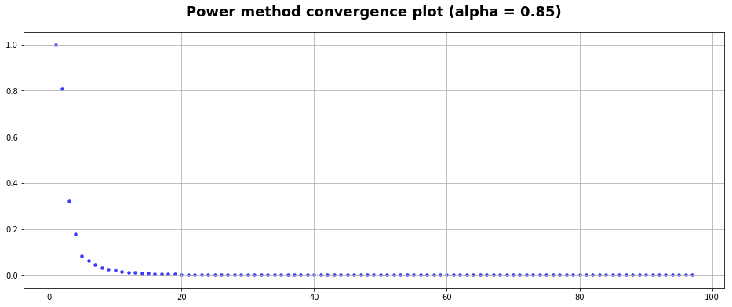

```python
%matplotlib inline

visualization_helper.plot_iterations_vs_error(pr_p_1ai.stats, size = (16, 6), title = 'Power method convergence plot (alpha = 0.85)')

pass;
```

Based on theory (see par. 3, pp. 3 and par. 5.1.1, pp. of [2]), we expect the algorithm to converge in accordance with the rate

$$ \left| \frac{\lambda_{2}}{\lambda_{1}} \right| \;\;\;\;\;\;\;\;\;\; \tag{1.a.i.1} $$

where $\lambda_{1}$, $\lambda_{2}$ are the $1st$ and $2nd$ dominant eigenvalues, respectively.

```python
eigenvalues_1ai = np.sort(-pr_p_1ai.x.toarray())
lambda_1_1ai = eigenvalues_1ai[0, 0]
lambda_2_1ai = eigenvalues_1ai[0, 1]

conv_rate_1ai = np.round(lambda_2_1ai / lambda_1_1ai, 3)

md('Convergence rate of the Power method: $%s$.' % conv_rate_1ai)
```

Convergence rate of the Power method: $0.814$.

(source: Wikipedia article on *Power iteration*, https://en.wikipedia.org/wiki/Power_iteration)

```python
est_iter_1ai = np.log10(1e-08) / np.log10(0.85)

md('Expected iterations for the convergence of the Power method: $%s$.' % np.floor(est_iter_1ai))
```

Expected iterations for the convergence of the Power method: $113.0$.

##### Save data for reference

```python
data_helper.np_save('output/pr_p_1ai_ranks', pr_p_1ai.ranks, fmt = 'bin')
data_helper.np_save('output/pr_p_1ai_stats', pr_p_1ai.stats, fmt = 'bin')

data_helper.np_save('output/pr_p_1ai_ranks.txt', pr_p_1ai.ranks, fmt = 'ascii')
data_helper.np_save('output/pr_p_1ai_stats.txt', pr_p_1ai.stats, fmt = 'ascii')
```

#### Answer 1.a.ii

##### Gauss-Seidel implementation, alpha = 0.85

In numerical linear algebra, the *Gauss–Seidel* method (see [3]), also known as the *Liebmann* method or the *method of successive displacement*, is an iterative method used to solve a linear system of equations. Though it can be applied to any matrix with non-zero elements on the diagonals, convergence is only guaranteed if the matrix is either diagonally dominant, or symmetric and positive definite.

Our goal in this context (see [5]) is to compute the Gauss-Seidel iterations of the form:

$$ x_{i}^{(k+1)} = (1-\alpha) + \alpha \sum_{j<i} a_{ij} x_{j}^{(k+1)} + \alpha \sum_{j>i} a_{ij} x_{j}^{(k)} \text{ } \forall i $$

Having tried multiples approache for the solution of the system, including iteratives ones, and having had very slow performance on iterative methods, I focused on an implementation that exploits the fact that the approximation to the solution of a generic linear system of equations $\mathbf{A} \mathbf{x} = \mathbf{b}$ can be written as:

$$ \mathbf{L} \mathbf{x}^{(k+1)} = \mathbf{b} - \mathbf{U} \mathbf{x}^{(k)} $$

where $\mathbf{x}^{(k)}$ is the k-th approximation of $\mathbf{x}$, $\mathbf{x}^{(k+1)}$ is the next iteration of $\mathbf{x}$ and $\mathbf{P}$ can be decomposed to a lower triangular matrix $\mathbf{L}$ and a strictly upper triangular matrix $\mathbf{U}$, such that $\mathbf{P} = \mathbf{L} + \mathbf{U}$ (see par. "Description" of [3], par. 5.4, pp. 19 of [4]).

Therefore, I broke down the matrix $\mathbf{P}$ to a lower triangular matrix $\mathbf{L}$ and a stricty triangular matrix $\mathbf{U}$, satisfying the properties described above, thereafter solving the linear system with the solver provided by *Scipy* within a cycle of iterations, until convergence was achieved.

The computation cost of the implementation breaks down to:

- LU factorization: $O(1)$, since this factorization is simply braking down $\mathbf{P}$ to a sum of matrices $\mathbf{L}$ and $\mathbf{U}$.
- Solution of a triangular system: $O(n^{2}) \times \text{count of linear systems}$

with a total cost of $O(1) + (O(n^{2}) \times \text{count of linear systems})$

```python
from IPython.display import Markdown as md
```

```python
# Import required classes, implemented for the homework.
sys.path.append('code')

from PageRank import PageRank
```

```python
# Create an instance of my PageRank class.
pr_gs_1aii = PageRank()
```

```python
# Get data as a sparse row matrix.
P_1aii = data_helper.sparse_row_matrix
```

```python
%%time

pr_gs_1aii = pr_gs_1aii.solve(P = P_1aii, alpha = 0.85, tol = 1e-08, method = 'gauss-seidel', verbose = False)
```

```
CPU times: user 20.6 s, sys: 924 ms, total: 21.5 s
Wall time: 21.5 s
```

```python
md('The algorithm converged in %i iterations.' % (pr_gs_1aii.iterations))
```

The algorithm converged in 47 iterations.

```python
md('Inspect the output of the algorithm:\n\n %s.' % pr_gs_1aii.x)
```

Inspect the output of the algorithm:

[6.97059963e-07 1.30988502e-04 1.06529244e-06 ... 7.01838197e-07 2.35992720e-06 1.93265625e-06].

```python
md('Inspect the first $50$ rankings:\n\n %s.' % (pr_gs_1aii.ranks)[0:50])
```

Inspect the first $50$ rankings:

[ 89073 226411 241454 134832 136821 68889 67756 69358 272442 251796 95163 119479 231363 186750 225872 234704 117152 167295 235496 262860 38342 105607 27904 272762 93778 60210 101161 198090 258348 81435 214128 34573 245659 170452 134375 93989 65463 113673 208086 151981 181701 132695 247241 259455 17781 77999 137632 176790 183004 221087].

##### Convergence plot of Gauss-Seidel method

The plot below displays the number of iterations the algorithm performed versus the computed error at each iteration.

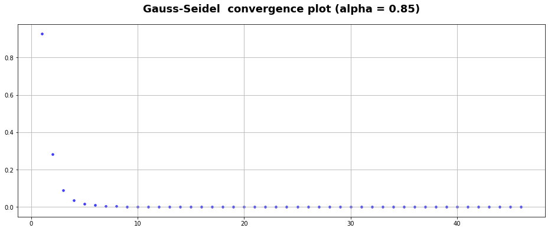

```python
%matplotlib inline

visualization_helper.plot_iterations_vs_error(pr_gs_1aii.stats, size = (16, 6), title = 'Gauss-Seidel  convergence plot (alpha = 0.85)')

pass;
```

##### Save data for reference

```python
data_helper.np_save('output/pr_gs_1aii_ranks', pr_gs_1aii.ranks, fmt = 'bin')
data_helper.np_save('output/pr_gs_1aii_stats', pr_gs_1aii.stats, fmt = 'bin')

data_helper.np_save('output/pr_gs_1aii_ranks.txt', pr_gs_1aii.ranks, fmt = 'ascii')
data_helper.np_save('output/pr_gs_1aii_stats.txt', pr_gs_1aii.stats, fmt = 'ascii')
```

#### Remarks of Part (a)

##### Are the results the same for both methods?

Let's print out the first $50$ ranked pages to inspect the results visually:

```python
pr_p_1ai_top_50 = pr_p_1ai.ranks[0:50].reshape(50)
pr_gs_1aii_top_50 = pr_gs_1aii.ranks[0:50].reshape(50)

ranks_comparison_df = pd.DataFrame(
    {
        'Power method (alpha = 0.85)': pr_p_1ai_top_50,
        'Gauss-Seidel (alpha = 0.85)': pr_gs_1aii_top_50,
        'Equal': pr_p_1ai_top_50 == pr_gs_1aii_top_50
    },
    index = np.arange(50)
)

ranks_comparison_df
```

|  | Power method (alpha = 0.85) | Gauss-Seidel (alpha = 0.85) | Equal |
| --- | --- | --- | --- |
| 0 | 89073 | 89073 | True |
| 1 | 226411 | 226411 | True |
| 2 | 241454 | 241454 | True |
| 3 | 134832 | 134832 | True |
| 4 | 136821 | 136821 | True |
| 5 | 68889 | 68889 | True |
| 6 | 67756 | 67756 | True |
| 7 | 69358 | 69358 | True |
| 8 | 272442 | 272442 | True |
| 9 | 251796 | 251796 | True |
| 10 | 95163 | 95163 | True |
| 11 | 119479 | 119479 | True |
| 12 | 231363 | 231363 | True |
| 13 | 186750 | 186750 | True |
| 14 | 225872 | 225872 | True |
| 15 | 234704 | 234704 | True |
| 16 | 117152 | 117152 | True |
| 17 | 167295 | 167295 | True |
| 18 | 235496 | 235496 | True |
| 19 | 262860 | 262860 | True |
| 20 | 38342 | 38342 | True |
| 21 | 105607 | 105607 | True |
| 22 | 27904 | 27904 | True |
| 23 | 272762 | 272762 | True |
| 24 | 93778 | 93778 | True |
| 25 | 60210 | 60210 | True |
| 26 | 101161 | 101161 | True |
| 27 | 198090 | 198090 | True |
| 28 | 258348 | 258348 | True |
| 29 | 81435 | 81435 | True |
| 30 | 214128 | 214128 | True |
| 31 | 34573 | 34573 | True |
| 32 | 245659 | 245659 | True |
| 33 | 170452 | 170452 | True |
| 34 | 134375 | 134375 | True |
| 35 | 93989 | 93989 | True |
| 36 | 65463 | 65463 | True |
| 37 | 113673 | 113673 | True |
| 38 | 208086 | 208086 | True |
| 39 | 151981 | 151981 | True |
| 40 | 181701 | 181701 | True |
| 41 | 132695 | 132695 | True |
| 42 | 247241 | 247241 | True |
| 43 | 259455 | 259455 | True |
| 44 | 137632 | 17781 | False |
| 45 | 183004 | 77999 | False |
| 46 | 176790 | 137632 | False |
| 47 | 221087 | 176790 | False |
| 48 | 17781 | 183004 | False |
| 49 | 77999 | 221087 | False |

```python
ranks_equal_a = np.count_nonzero(pr_p_1ai.ranks == pr_gs_1aii.ranks)

md('Number of equal rankings (α = $0.85$): $%s$.' % ranks_equal_a)
```

Number of equal rankings (α = $0.85$): $158865$.

```python
ranks_equal_perc_a = np.round((np.count_nonzero(pr_p_1ai.ranks == pr_gs_1aii.ranks) / np.unique(np.concatenate([data_helper.dataframe[0], data_helper.dataframe[1]])).shape[0]), 3)

md('Percentage of equals over all rankings: $%s$.' % ranks_equal_perc_a)
```

Percentage of equals over all rankings: $0.564$.

##### Which method seems to be faster?

From theory we can expect that the *Gauss-Seidel* method is expected to converge at lower iterations, for the same tolerance value, when compared to the *Power method*.

As a final note on performance improvement for the *Power method*, given more time I would implement the improvements described in par. 5.1.2, pp. 11 of [2], namely segmentation of dangling and non-dangling nodes of the $\mathbf{P}$ matrix.

### Part (b)

Do the previous task with $\alpha$ = 0.99. Your remarks on the convergence speed. Did the ranking of the first 50 nodes changed?

#### Answer 1.b

##### Power method method, alpha = 0.99

```python
from IPython.display import Markdown as md
```

```python
# Import required classes, implemented for the homework.
sys.path.append('code')

from PageRank import PageRank
from VisualizationHelper import VisualizationHelper
```

```python
# Create an instance of my PageRank class.
pr_p_1b = PageRank()
```

```python
# Get data as a sparse row matrix.
P_p_1b = data_helper.sparse_row_matrix
```

```python
%%time

pr_p_1b = pr_p_1b.solve(P = P_p_1b, alpha = 0.99, tol = 1e-08, method = 'power', verbose = False)
```

```
CPU times: user 2min 3s, sys: 4.18 s, total: 2min 7s
Wall time: 2min 7s
```

```python
md('The algorithm converged in $%i$ iterations.' % (pr_p_1b.iterations))
```

The algorithm converged in $1613$ iterations.

```python
md('Inspect the output of the algorithm:\n\n %s.' % pr_p_1b.x.toarray()[0])
```

Inspect the output of the algorithm:

[3.56430399e-08 3.94535697e-05 7.53399870e-08 ... 3.59276093e-08 3.96093232e-07 1.85332168e-07].

```python
md('Inspect the first $50$ rankings:\n\n %s.' % pr_p_1b.ranks[:50])
```

Inspect the first $50$ rankings:

[136821 68889 95163 272442 251796 119479 117152 235496 27904 272762 89073 226411 14356 281772 208086 97623 187453 91620 192935 113673 70563 226247 3408 203322 241454 114813 213780 114666 64737 174665 165950 129971 95363 181022 160448 55087 215184 255471 197668 138869 164067 22794 24726 194930 118948 116869 11508 9752 96567 93284].

Plot iterations versus error (convergence metric)

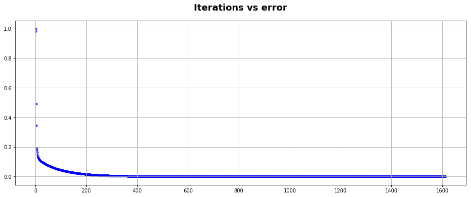

```python
%matplotlib inline

visualization_helper = VisualizationHelper()
visualization_helper.plot_iterations_vs_error(pr_p_1b.stats, size = (16, 6), title = 'Iterations vs error')

pass;
```

```python
data_helper.np_save('output/pr_p_1b_ranks', pr_p_1b.ranks, fmt = 'bin')
data_helper.np_save('output/pr_p_1b_stats', pr_p_1b.stats, fmt = 'bin')

data_helper.np_save('output/pr_p_1b_ranks.txt', pr_p_1b.ranks, fmt = 'ascii')
data_helper.np_save('output/pr_p_1b_stats.txt', pr_p_1b.stats, fmt = 'ascii')
```

##### Gauss-Seidel method, alpha = 0.99

```python
from IPython.display import Markdown as md
```

```python
# Import required classes, implemented for the homework.
sys.path.append('code')

from PageRank import PageRank
```

```python
# Create an instance of my PageRank class.
pr_gs_1b = PageRank()
```

```python
# Get data as a sparse row matrix.
P_gs_1b = data_helper.sparse_row_matrix
```

```python
%%time

pr_gs_1b = pr_gs_1b.solve(P = P_gs_1b, alpha = 0.99, tol = 1e-08, method = 'gauss-seidel', verbose = False)
```

```
CPU times: user 4min 18s, sys: 30.5 ms, total: 4min 18s
Wall time: 4min 18s
```

```python
md('The algorithm converged in $%i$ iterations.' % (pr_gs_1b.iterations))
```

The algorithm converged in $581$ iterations.

```python
md('Inspect the output of the algorithm:\n\n %s.' % pr_gs_1b.x)
```

Inspect the output of the algorithm:

[7.70526511e-08 8.52902041e-05 1.62868985e-07 ... 7.76678296e-08 8.56269098e-07 4.00648624e-07].

```python
md('Inspect the first $50$ rankings:\n\n %s.' % (pr_gs_1b.ranks)[0:50])
```

Inspect the first $50$ rankings:

[136821 68889 272442 251796 95163 119479 117152 235496 27904 272762 89073 226411 14356 281772 208086 97623 187453 91620 192935 113673 70563 226247 3408 203322 241454 114813 213780 114666 64737 174665 165950 129971 95363 181022 160448 55087 215184 255471 197668 22794 138869 164067 24726 118948 194930 116869 11508 9752 96567 93284].

Plot iterations versus error (convergence metric)

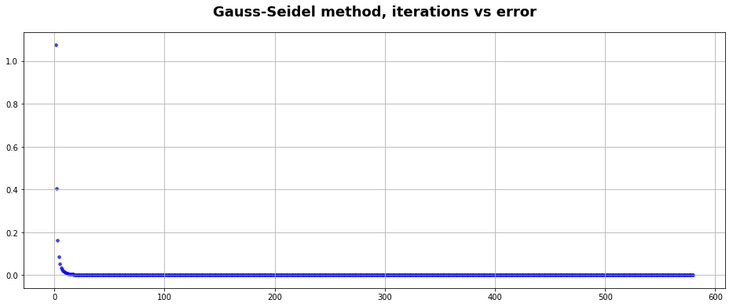

```python
%matplotlib inline

visualization_helper.plot_iterations_vs_error(pr_gs_1b.stats, size = (16, 6), title = 'Gauss-Seidel method, iterations vs error')

pass;
```

```python
data_helper.np_save('output/pr_gs_1b_ranks', pr_gs_1b.ranks, fmt = 'bin')
data_helper.np_save('output/pr_gs_1b_stats', pr_gs_1b.stats, fmt = 'bin')

data_helper.np_save('output/pr_gs_1b_ranks.txt', pr_gs_1b.ranks, fmt = 'ascii')
data_helper.np_save('output/pr_gs_1b_stats.txt', pr_gs_1b.stats, fmt = 'ascii')
```

##### Are the results the same for both methods?

Let's print out the first $50$ ranked pages to inspect the results visually:

```python
pr_p_1b_top_50 = pr_p_1b.ranks[0:50].reshape(50)
pr_gs_1b_top_50 = pr_gs_1b.ranks[0:50].reshape(50)

ranks_comparison_df = pd.DataFrame(
    {
        'Power method (alpha = 0.99)': pr_p_1b_top_50,
        'Gauss-Seidel (alpha = 0.99)': pr_gs_1b_top_50,
        'Equal': pr_p_1b_top_50 == pr_gs_1b_top_50
    },
    index = np.arange(50)
)

ranks_comparison_df
```

|  | Power method (alpha = 0.99) | Gauss-Seidel (alpha = 0.99) | Equal |
| --- | --- | --- | --- |
| 0 | 136821 | 136821 | True |
| 1 | 68889 | 68889 | True |
| 2 | 95163 | 272442 | False |
| 3 | 272442 | 251796 | False |
| 4 | 251796 | 95163 | False |
| 5 | 119479 | 119479 | True |
| 6 | 117152 | 117152 | True |
| 7 | 235496 | 235496 | True |
| 8 | 27904 | 27904 | True |
| 9 | 272762 | 272762 | True |
| 10 | 89073 | 89073 | True |
| 11 | 226411 | 226411 | True |
| 12 | 14356 | 14356 | True |
| 13 | 281772 | 281772 | True |
| 14 | 208086 | 208086 | True |
| 15 | 97623 | 97623 | True |
| 16 | 187453 | 187453 | True |
| 17 | 91620 | 91620 | True |
| 18 | 192935 | 192935 | True |
| 19 | 113673 | 113673 | True |
| 20 | 70563 | 70563 | True |
| 21 | 226247 | 226247 | True |
| 22 | 3408 | 3408 | True |
| 23 | 203322 | 203322 | True |
| 24 | 241454 | 241454 | True |
| 25 | 114813 | 114813 | True |
| 26 | 213780 | 213780 | True |
| 27 | 114666 | 114666 | True |
| 28 | 64737 | 64737 | True |
| 29 | 174665 | 174665 | True |
| 30 | 165950 | 165950 | True |
| 31 | 129971 | 129971 | True |
| 32 | 95363 | 95363 | True |
| 33 | 181022 | 181022 | True |
| 34 | 160448 | 160448 | True |
| 35 | 55087 | 55087 | True |
| 36 | 215184 | 215184 | True |
| 37 | 255471 | 255471 | True |
| 38 | 197668 | 197668 | True |
| 39 | 138869 | 22794 | False |
| 40 | 164067 | 138869 | False |
| 41 | 22794 | 164067 | False |
| 42 | 24726 | 24726 | True |
| 43 | 194930 | 118948 | False |
| 44 | 118948 | 194930 | False |
| 45 | 116869 | 116869 | True |
| 46 | 11508 | 11508 | True |
| 47 | 9752 | 9752 | True |
| 48 | 96567 | 96567 | True |
| 49 | 93284 | 93284 | True |

I have visually observed that, within the first $50$ pages, the majority of ranks are equal for both algorithms. Even in cases that the rank positions do not match 1-for-1, the respective rankings are a few positions off.

The count of equal rankings of the first $50$ ranks is:

```python
md('Number of equal rankings (α = $0.99$): $%s$.' % np.count_nonzero(pr_p_1b.ranks[0:50] == pr_gs_1b.ranks[0:50]))
```

Number of equal rankings (α = $0.99$): $42$.

The count of total equal rankings of the first ranks is:

```python
md('Number of equal rankings (α = $0.99$): $%s$.' % np.count_nonzero(pr_p_1b.ranks == pr_gs_1b.ranks))
```

Number of equal rankings (α = $0.99$): $147508$.

The percentage of equal over all rankings is:

```python
md('Percentage of equal over all rankings: $%s$.' % (np.count_nonzero(pr_p_1b.ranks == pr_gs_1b.ranks) / np.unique(np.concatenate([data_helper.dataframe[0], data_helper.dataframe[1]])).shape[0]))
```

Percentage of equal over all rankings: $0.5232580000922303$.

Let us now verify whether the different methods produce equal results for different values of $\alpha$:

```python
pr_p_1ai_top_50 = pr_p_1ai.ranks[0:50].reshape(50)
pr_gs_1aii_top_50 = pr_gs_1aii.ranks[0:50].reshape(50)
pr_p_1b_top_50 = pr_p_1b.ranks[0:50].reshape(50)
pr_gs_1b_top_50 = pr_gs_1b.ranks[0:50].reshape(50)

ranks_comparison_df = pd.DataFrame(
    {
        'Power method (alpha = 0.85)': pr_p_1ai_top_50,
        'Power method (alpha = 0.99)': pr_gs_1aii_top_50,
        'Gauss-Seidel (alpha = 0.85)': pr_p_1b_top_50,
        'Gauss-Seidel (alpha = 0.99)': pr_gs_1b_top_50
    },
    index = np.arange(50)
)

ranks_comparison_df
```

[output not shown]

I observe that the rankings have changed.

### Part (c)

When we use the power method do all the components of $\pi$ converge at the same speed to their limits? If not which of the converge faster: those that correspond to important nodes or to non important ? Do you observe the same behavior when you find $\pi$ through the solution of the linear system?

#### Convergence

For identifying convergence conditions, I kept track of the order of rankings per iterations, so as to acquire a time-series structure of the evolution of convergence throughout the iterations of the algorithms. The structure effectively contains the descending order sorted stationary solution $\pi$ of the Markov chain for each iteration.

To visualize and interpret the outcome of the time series, I implemented a process of graphing the flunctuations of the top-n nodes across the time component (iterations step) of the aforementioned structure, the results of which are presented below.

Each graph presents the top $20$ top-ranking nodes and the last $20$ nodes of the stationary vector, approximately. The hypothesis is that nodes that converge at earlier iteration stages should present small flunctuations in their position initially, presented as a jagged line in the graph, while flattening-out quite early in the epoch and continuing to be graphed as a line parallel to the x-axis of the graph. In this context, an epoch is a set of iterations the algorithm performs until ultimately converging.

Indeed, comparing the graphs that follow, I conclude the following:

- The *Power method* exhibits the characteristic that more important nodes converge earlier in the epoch.
- *Gauss-Seidel* also exhibits the characteristic that more important nodes converge earlier in the epoch.

**Note**, however, that the *Power method* exhibits some anomalies for a few of the nodes presented below. This may be an indication that there is a glitch in my implementation which, given more time could be remedied.

##### Power method

###### Convergence graph of top 20 rankings ($\alpha = 0.85$)

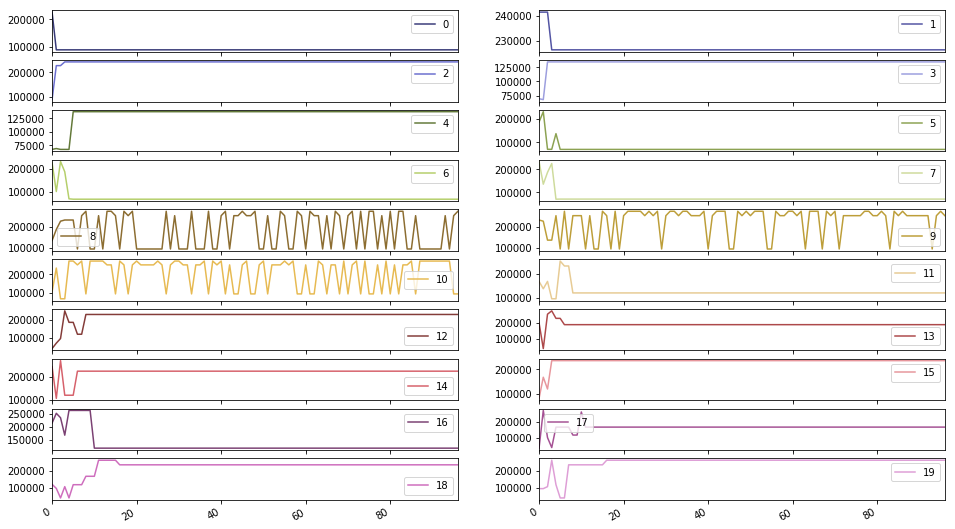

```python
visualization_helper.plot_ranks_convergence(pr_p_1ai.per_iteration_convergence, from_ranking = 0, to_ranking = 20, size = (16, 10))

pass;
```

###### Convergence graph of last 20 rankings (Power method, $\alpha = 0.85$)

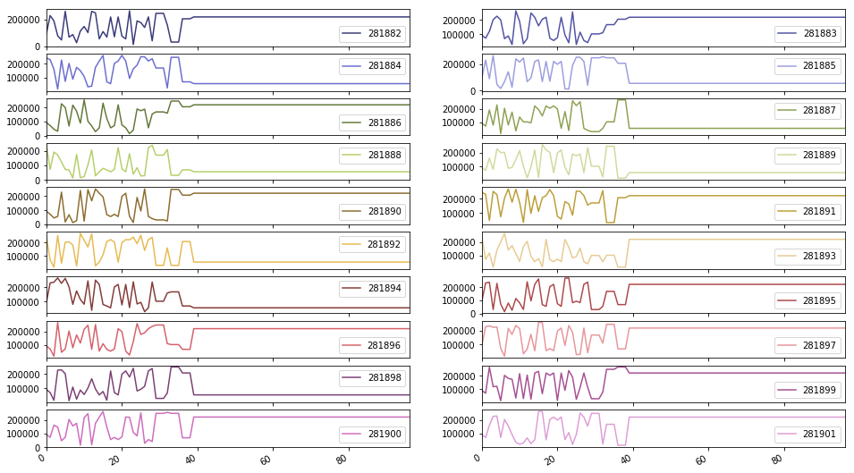

```python
visualization_helper.plot_ranks_convergence(pr_p_1ai.per_iteration_convergence, from_ranking = pr_p_1ai.per_iteration_convergence.shape[1] - 21, to_ranking = pr_p_1ai.per_iteration_convergence.shape[1] - 1, size = (16, 10))

pass;
```

###### Convergence graph of top 20 rankings (Power method, $\alpha = 0.99$)

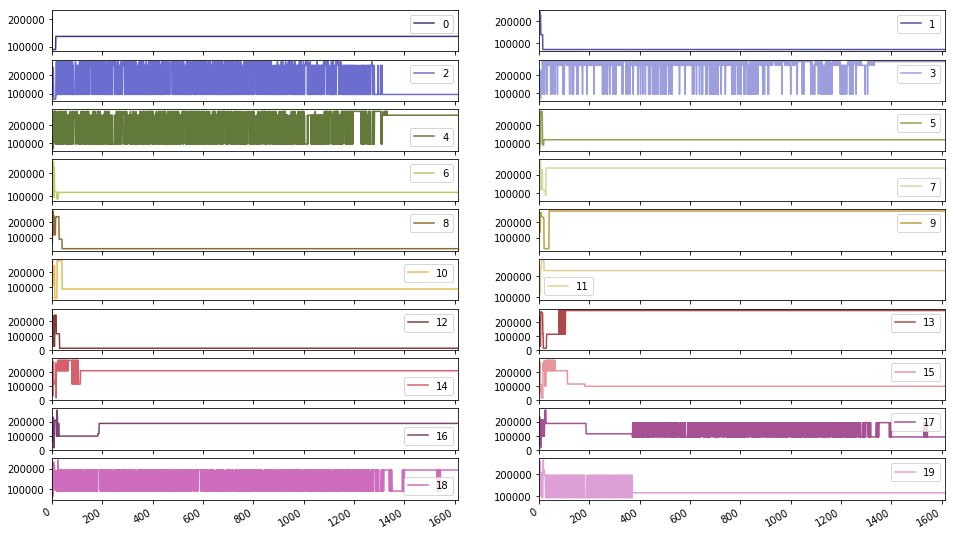

```python
visualization_helper.plot_ranks_convergence(pr_p_1b.per_iteration_convergence, from_ranking = 0, to_ranking = 20, size = (16, 10))

pass;
```

###### Convergence graph of last 20 rankings (Power method, $\alpha = 0.99$)

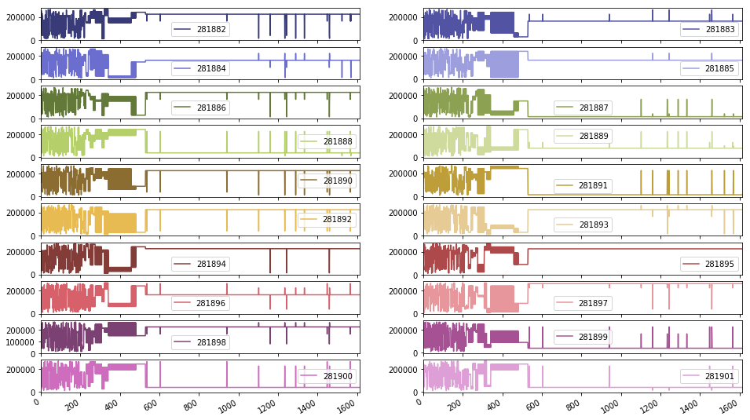

```python
visualization_helper.plot_ranks_convergence(pr_p_1b.per_iteration_convergence, from_ranking = pr_p_1b.per_iteration_convergence.shape[1] - 21, to_ranking = pr_p_1b.per_iteration_convergence.shape[1] - 1, size = (16, 10))

pass;
```

##### Gauss-Seidel

###### Convergence graph of top 20 rankings (Gauss-Seidel, $\alpha = 0.85$)

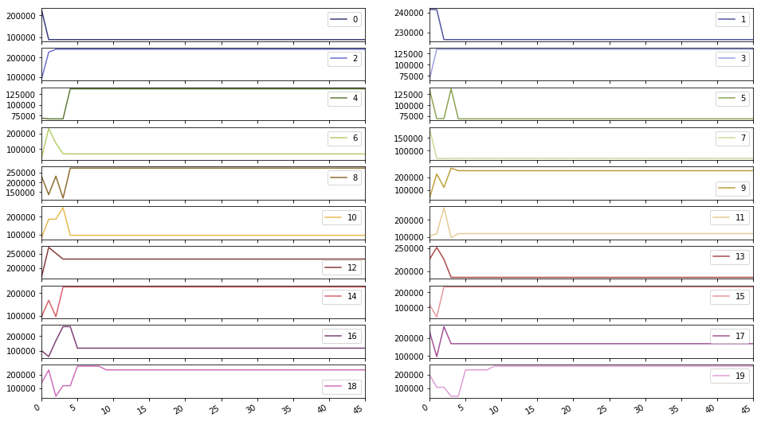

```python
visualization_helper.plot_ranks_convergence(pr_gs_1aii.per_iteration_convergence, from_ranking = 0, to_ranking = 20, size = (16, 10))

pass;
```

###### Convergence graph of last 20 rankings (Gauss-Seidel, $\alpha = 0.85$)

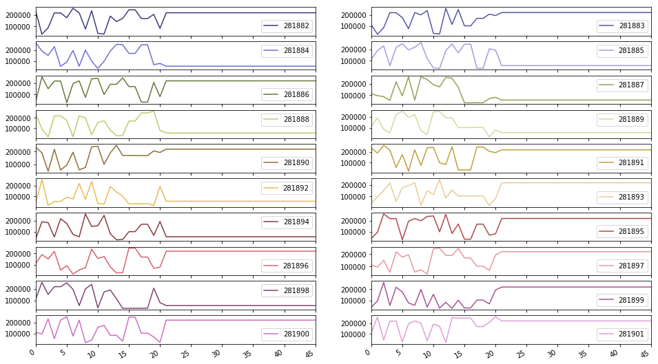

```python
visualization_helper.plot_ranks_convergence(pr_gs_1aii.per_iteration_convergence, from_ranking = pr_gs_1aii.per_iteration_convergence.shape[1] - 21, to_ranking = pr_gs_1aii.per_iteration_convergence.shape[1] - 1, size = (16, 10))

pass;
```

###### Convergence graph of top 20 rankings (Gauss-Seidel, $\alpha = 0.99$)

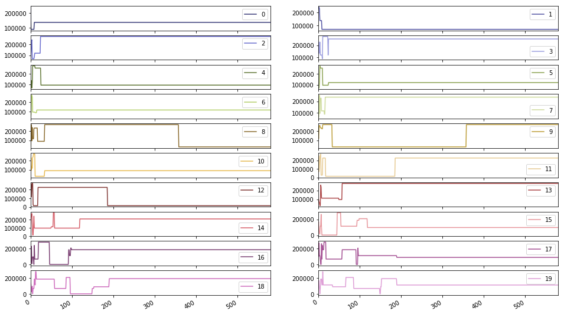

```python
visualization_helper.plot_ranks_convergence(pr_gs_1b.per_iteration_convergence, from_ranking = 0, to_ranking = 20, size = (16, 10))

pass;
```

###### Convergence graph of last 20 rankings (Gauss-Seidel, $\alpha = 0.99$)

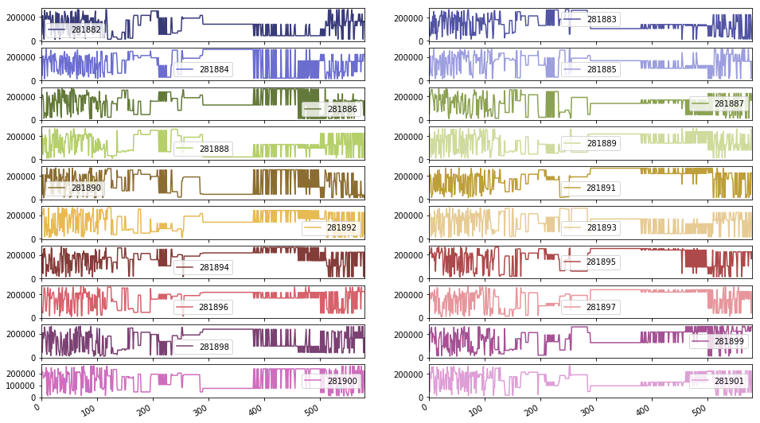

```python
visualization_helper.plot_ranks_convergence(pr_gs_1b.per_iteration_convergence, from_ranking = pr_gs_1b.per_iteration_convergence.shape[1] - 21, to_ranking = pr_gs_1b.per_iteration_convergence.shape[1] - 1, size = (16, 10))

pass;
```

## Part (2)

A typical way to raise the PageRank of a page is to use ?link farms?, i.e., a collection of ?fake? pages that point to yours in order to improve its PageRank. Our goal in this problem is to do a little analysis of the design of link farms, and how their structure affects the PageRank calculations. Consider the web graph. It contains $n$ pages, labeled 1 through $n$: Of course, $n$ is very large. As mentioned in, we use the notation $G = \alpha P + \frac{1 − \alpha}{n} I$ for the transition matrix. Let $\pi_{i}$ i denote the PageRank of page $i$ and $\pi = (\pi_{1}, \pi_{2}, \cdots \pi_{n})$ denote the vector of PageRanks of all pages. Note: For a page that has $k$ outgoing links, we put 1 = $k$ for the corresponding entries of $P$: However, when a webpage has no outgoing links, we add a 1 as the corresponding diagonal element of $P$ for making its row-sum one. Note that this makes $G$ a valid transition probability matrix.

### Import 3rd-party and bespoke packages

```python
# Import required packages.
import sys
import warnings
import numpy as np
import pandas as pd
import networkx as nx
from IPython.display import Markdown as md

warnings.filterwarnings('ignore')
```

```python
# Import required classes, implemented for the homework.
sys.path.append('code')

from DataHelper import DataHelper
from VisualizationHelper import VisualizationHelper
```

### Ingest and transform data

```python
data_helper = DataHelper()
visualization_helper = VisualizationHelper()
```

```python
%%time

# Ingest the data file as a Pandas DataFrame.
data_helper = data_helper.ingest_data('stanweb.dat')
```

```
CPU times: user 21 s, sys: 224 ms, total: 21.2 s
Wall time: 21.2 s
```

### Part (a)

You now create a new web page $X$ (thus adding a node to the web graph). $X$ has neither in-links, nor out-links. Let $\tilde{\pi} = (\tilde{\pi_{1}}, \tilde{\pi_{2}}, \cdots , \tilde{\pi_{n}})$ denote the vector of new PageRanks of the $n$ old web pages, and $x$ denote the new PageRank of page $X$: In other words, $(\tilde{\pi_{1}}, \tilde{\pi_{2}}, \cdots , \tilde{\pi_{n}}, x)$ is the PageRank vector of the new web graph. Write $\tilde{\pi}$ and $x$ in terms of $r$: Comment on how the PageRanks of the older pages changed due to the addition of the new page (remember $n$ is a very large number). Hint: Use the stationary equations to calculate PageRank,not the iterative approach.

#### Creation of node X

We insert a new page in the dataframe obtained by the original data:

```python
# Create node X.
X = 281904
inlinks = None
outlinks = None

# Add page X.
data_helper = data_helper.add_page(X, inlinks, outlinks)
```

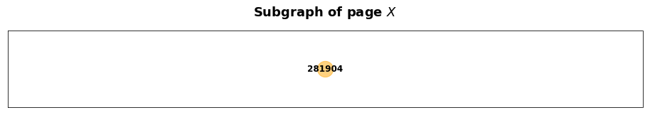

```python
subgraph = data_helper.graph.subgraph([X])

visualization_helper.plot_graph(subgraph, highlight_nodes = [X], size = (16, 2), title = 'Subgraph of page $X$')

pass;
```

As expected, page $X$ has neither incoming or outgoing links.

#### Computation of *PageRank* with the *Power method* for evaluating the rank of X

```python
# Get data as a sparse row matrix.
P_2a = data_helper.sparse_row_matrix
```

```python
# Create an instance of my PageRank class.
pr_p_2a = PageRank()
```

```python
%%time

pr_p_2a = pr_p_2a.solve(P = P_2a, alpha = 0.85, tol = 1e-08, method = 'power', verbose = False)
```

```
CPU times: user 7.31 s, sys: 40.1 ms, total: 7.35 s
Wall time: 7.27 s
```

```python
md('The algorithm converged in $%i$ iterations.' % (pr_p_2a.iterations))
```

The algorithm converged in $98$ iterations.

```python
md('Rank of X is $%s$.' % np.where(pr_p_2a.ranks == X)[0][0])
```

Rank of X is $42593$.

### Part (b)

Unsatisfied with the PageRank of your page $X$; you create another page $Y$ (with no in-links) that links to $X$: What are the PageRanks of all the $n + 2$ pages now? Does the PageRank of $X$ improve?

#### Creation of node Y

```python
# Create node Y.
Y = 281905
inlinks = None
outlinks = np.array([[X, 1.0]])

# Add node Y.
data_helper = data_helper.add_page(Y, inlinks, outlinks)
```

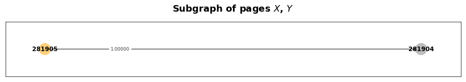

```python
subgraph = data_helper.graph.subgraph([X, Y])

visualization_helper.plot_graph(subgraph, highlight_nodes = [Y], size = (16, 2), title = 'Subgraph of pages $X$, $Y$')

pass;
```

Page $Y$ indeed has no incoming links and links to page $X$.

#### Computation of *PageRank* with the *Power method* for evaluating the rank of X

```python
# Get data as a sparse row matrix.
P_2b = data_helper.sparse_row_matrix
```

```python
# Create an instance of my PageRank class.
pr_gs_2b = PageRank()
```

```python
%%time

pr_gs_2b = pr_gs_2b.solve(P = P_2b, alpha = 0.85, tol = 1e-08, method = 'power', verbose = False)
```

```
CPU times: user 7.43 s, sys: 35.8 ms, total: 7.47 s
Wall time: 7.38 s
```

```python
md('The algorithm converged in $%i$ iterations.' % (pr_gs_2b.iterations))
```

The algorithm converged in $98$ iterations.

```python
md('Rank of X is $%s$.' % np.where(pr_gs_2b.ranks == X)[0][0])
```

Rank of X is $141864$.

```python
md('Rank of Y is $%s$.' % np.where(pr_gs_2b.ranks == Y)[0][0])
```

Rank of Y is $281904$.

I observe that the ranking of $X$ decreases.

### Part (c)

Still unsatisfied, you create a third page $Z$: How should you set up the links on your three pages so as to maximize the PageRank of $X$?

#### Creation of node Z

It makes sense that pages with incoming links should be considered more "valuable", therefore we should set up our pages such that $Z$ has an outgoing link to $Y$ and $Y$ to $X$.

```python
# Create node Z.
Z = 281906
inlinks = None
outlinks = np.array([[Y, 1.0]])

# Add node Z.
data_helper = data_helper.add_page(Z, inlinks, outlinks)
```

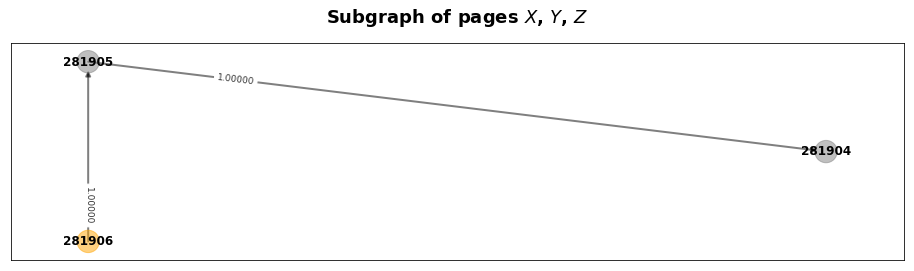

```python
subgraph = data_helper.graph.subgraph([X, Y, Z])

visualization_helper.plot_graph(subgraph, highlight_nodes = [Z], size = (16, 4), title = 'Subgraph of pages $X$, $Y$, $Z$')

pass;
```

#### Computation of *PageRank* with the *Power method* for evaluating the rank of X

```python
# Get data as a sparse row matrix.
P_2c = data_helper.sparse_row_matrix
```

```python
# Create an instance of my PageRank class.
pr_gs_2c = PageRank()
```

```python
%%time

pr_gs_2c = pr_gs_2c.solve(P = P_2c, alpha = 0.85, tol = 1e-08, method = 'power', verbose = False)
```

```
CPU times: user 7.33 s, sys: 16 ms, total: 7.35 s
Wall time: 7.29 s
```

```python
md('The algorithm converged in $%i$ iterations.' % (pr_gs_2c.iterations))
```

The algorithm converged in $98$ iterations.

```python
md('Rank of X is $%s$.' % np.where(pr_gs_2c.ranks == X)[0][0])
```

Rank of X is $107045$.

```python
md('Rank of Y is $%s$.' % np.where(pr_gs_2c.ranks == Y)[0][0])
```

Rank of Y is $141877$.

```python
md('Rank of Z is $%s$.' % np.where(pr_gs_2c.ranks == Z)[0][0])
```

Rank of Z is $281905$.

### Part (d)

You have one last idea, you add links from your page $X$ to older, popular pages (e.g.: you add a list of ?Useful links? on your page). Does this improve the PageRank of $X$? Does the answer change if you add links from $Y$ or $Z$ to older, popular pages?

#### Linking out from X

I shall attempt to link page $X$ to the top-10 pages, as ranked by the *Power method* algorithm of Part 1.a.i.

```python
# Top-10 ranked pages.
k = 10

top_k_ranks = pr_p_1ai.ranks[0:k]
top_k_ranks_with_weights = np.zeros((k, 2))

# Assign weights.
for i in range(0, k):
    top_k_ranks_with_weights[i, 0] = top_k_ranks[i]
    top_k_ranks_with_weights[i, 1] = 1 / k

# Create node X.
X = 281904
inlinks = None
outlinks = top_k_ranks_with_weights

# Add page X.
data_helper = data_helper.add_page(X, inlinks, outlinks)
```

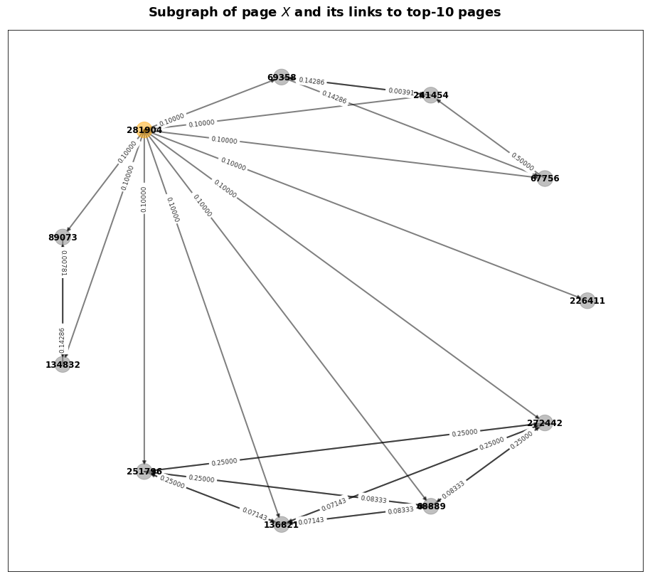

```python
subgraph = data_helper.graph.subgraph(np.concatenate([[X], top_k_ranks]))

visualization_helper.plot_graph(subgraph, highlight_nodes = [X], size = (16, 14), title = 'Subgraph of page $X$ and its links to top-10 pages')

pass;
```

#### Computation of *PageRank* with the *Power method* for evaluating the rank of X

```python
# Get data as a sparse row matrix.
P_2d = data_helper.sparse_row_matrix
```

```python
# Create an instance of my PageRank class.
pr_p_2d = PageRank()
```

```python
%%time

pr_p_2d = pr_p_2d.solve(P = P_2d, alpha = 0.85, tol = 1e-08, method = 'power', verbose = False)
```

```
CPU times: user 7.29 s, sys: 0 ns, total: 7.29 s
Wall time: 7.28 s
```

```python
md('The algorithm converged in $%i$ iterations.' % (pr_p_2d.iterations))
```

The algorithm converged in $98$ iterations.

```python
md('Rank of X is $%s$.' % np.where(pr_p_2d.ranks == X)[0][0])
```

Rank of X is $107045$.

#### Linking out from Y and Z

```python
# Top-10 ranked pages.
k = 10

top_k_ranks = pr_p_1ai.ranks[0:k]
top_k_ranks_with_weights = np.zeros((k, 2))

# Assign weights.
for i in range(0, k):
    top_k_ranks_with_weights[i, 0] = top_k_ranks[i]
    top_k_ranks_with_weights[i, 1] = 1 / k

# Create node X.
X = 281904
inlinks = None
outlinks = top_k_ranks_with_weights

# Add page X.
data_helper = data_helper.add_page(X, inlinks, outlinks)

# Create node Y.
Y = 281905
inlinks = None
outlinks = top_k_ranks_with_weights

# Add page Y.
data_helper = data_helper.add_page(Y, inlinks, outlinks)

# Create node Z.
Z = 281906
inlinks = None
outlinks = top_k_ranks_with_weights

# Add page Z.
data_helper = data_helper.add_page(Z, inlinks, outlinks)
```

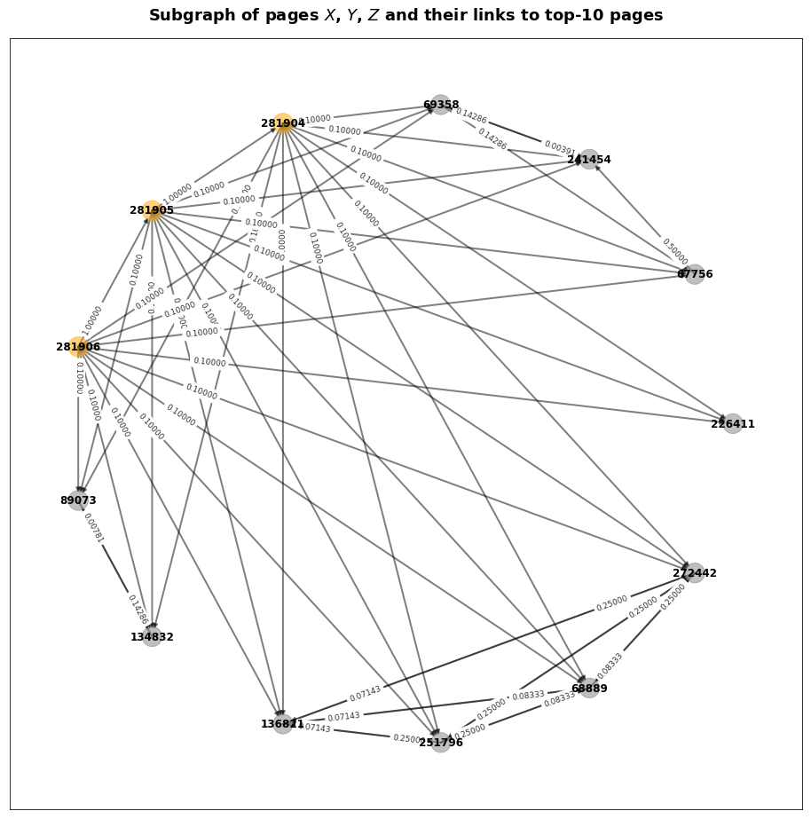

```python
subgraph = data_helper.graph.subgraph(np.concatenate([[X, Y, Z], top_k_ranks]))

visualization_helper.plot_graph(subgraph, highlight_nodes = [X, Y, Z], size = (16, 16), title = 'Subgraph of pages $X$, $Y$, $Z$ and their links to top-10 pages')

pass;
```

#### Computation of *PageRank* with the *Power method* for evaluating the rank of X

```python
# Get data as a sparse row matrix.
P_2d = data_helper.sparse_row_matrix
```

```python
# Create an instance of my PageRank class.
pr_p_2d = PageRank()
```

```python
%%time

pr_p_2d = pr_p_2d.solve(P = P_2d, alpha = 0.85, tol = 1e-08, method = 'power', verbose = False)
```

```
CPU times: user 7.27 s, sys: 0 ns, total: 7.27 s
Wall time: 7.27 s
```

```python
md('The algorithm converged in $%i$ iterations.' % (pr_p_2d.iterations))
```

The algorithm converged in $98$ iterations.

```python
md('Rank of X is $%s$.' % np.where(pr_p_2d.ranks == X)[0][0])
```

Rank of X is $107045$.

I observe that ranking of $X$ hasn't changed, despite the fact that the *useful links* section has been added to pages $Y$ and $Z$.

### Part (e)

Describe what steps you might take to raise the PageRank of $X$ further. You do not need to prove anything here, just summarize your thoughts based on the previous parts. For extra credit though, you can prove what the structure for a link farm with $m$ nodes should be to optimize the PageRank of $X$.

#### Improving PageRank of X

Quoting [6], "*PageRank works by counting the number and quality of links to a page to determine a rough estimate of how important the website is. The underlying assumption is that more important websites are likely to receive more links from other websites.*".

Further, in [6] it is also mentioned that increasing the PageRank of a page can be achieved by having one or more high-value pages link to it. In fact, this method is a means of marketing and exploitation on the part of high-value websites.

Therefore, increasing the PageRank of $X$ would require us to have links for top-n ranked pages toward $X$.

## References

[1] Wikipedia article on *Power iteration*.

Source: https://en.wikipedia.org/wiki/Power_iteration

[2] Langville, Amy & Meyer, Carl. (2004). Deeper Inside PageRank. Internet Mathematics. 1. 10.1080/15427951.2004.10129091.

[3] Wikipedia article on *Gauss-Seidel*.

Source: https://en.wikipedia.org/wiki/Gauss%E2%80%93Seidel_method

[4] M. (Rien) den Besten, The PageRank Problem - Thesis for the degree of Bachelor of Science in Applied Mathematics, Delft, The Netherlands, August 2010.

Source: https://repository.tudelft.nl/islandora/object/uuid:0483fd00-117d-43a3-b61f-6ce8a178e709/datastream/OBJ/download

[5] Arvind Arasu, Jasmine Novak, Andrew Tomkins, and John Tomlin. PageRank computation and the structure of the Web: experiments and algorithms. In The Eleventh International WWW Conference, New York, May 2002. ACM Press.

Source: http://www.w3c.ethz.ch/CDstore/www2002/poster/173.pdf

[6] Wikipedia article on PageRank.

Source: https://en.wikipedia.org/wiki/PageRank

```python
from IPython.display import HTML

HTML(
    '''
    <script>
        code_show = true;

        function code_toggle() {
            if (code_show){
                $('div.input').hide();
            }
            else {
                $('div.input').show();
            }

            code_show = !code_show
        }
        $(document).ready(code_toggle);
    </script>
    <form action="javascript:code_toggle()"><input type="submit" value="Toggle code"></form>
    '''
)
```